# capstone_markdown

Jake Daniels

July 9, 2018

# Data Prep and CLean

Cleaning & Visual Packages Required

```r
#install.packages("tidyverse")
#install.packages("gmodels")
#install.packages("plotly")
#install.packages("reshape2")
library(tidyverse)
library(gmodels)
library(plotly)
library(reshape2)
```

Loading in Data from AWS MySQL

```r
#install.packages("DBI")
library(DBI)
#install.packages("RMySQL")
library(RMySQL)
# Utilizing .Renviron to mask sensitive information
cn <- dbConnect(drv      = RMySQL::MySQL(),
                username = "root",
                password = Sys.getenv("MY_PASS"),
                host     = Sys.getenv("MY_HOST"),
                port     = 3306,
                dbname   = "capstoneryersonMYSQL")

Billing <- dbGetQuery(cn, "SELECT * FROM Billing;")
Customer <- dbGetQuery(cn, "SELECT * FROM Customer;")
CustService <- dbGetQuery(cn, "SELECT * FROM CustServ;")
Operations <- dbGetQuery(cn, "SELECT * FROM Operations;")
Product <- dbGetQuery(cn, "SELECT * FROM Product;")
Service <- dbGetQuery(cn, "SELECT * FROM Service;")
dbDisconnect(cn)
```

```
## [1] TRUE
```

Execute Script: R - Correcting NA Values.R

```r
# had to create a script as a workaround for NA numerics values defaulting to 0 when pulled from RDBMS,
# manually inserting with script
library(knitr)
opts_chunk$set(echo = FALSE, cache=FALSE)
read_chunk('~/ryersoncapstone1/2) Data Prep & Clean/R - Correcting NA Values.R')
```

Combining all tables to make dropping rows consistent when cleaning

Univariate Cleaning NA/OUTLIER for Models

Billing

Class Types and Structure

```
## Observations: 100,000
## Variables: 13
## $ Customer_ID <chr> "1000001", "1000002", "1000003", "1000004", "10000...
## $ rev_Mean    <dbl> 23.998, 57.493, 16.990, 38.000, 55.230, 82.275, 17...
## $ totmrc_Mean <dbl> 22.500, 37.425, 16.990, 38.000, 71.980, 75.000, 16...
## $ ovrrev_Mean <dbl> 0.000, 9.100, 0.000, 0.000, 0.000, 0.000, 0.000, 0...
## $ vceovr_Mean <dbl> 0.000, 9.100, 0.000, 0.000, 0.000, 0.000, 0.000, 0...
## $ datovr_Mean <dbl> 0.000, 0.000, 0.000, 0.000, 0.000, 0.000, 0.000, 0...
## $ change_rev  <dbl> -18.998, 50.988, 0.000, 0.000, 0.000, 8.145, -0.15...
## $ totrev      <dbl> 1504.62, 2851.68, 2155.91, 2000.90, 2181.12, 4033....
## $ adjrev      <dbl> 1453.44, 2833.88, 1934.47, 1941.81, 2166.48, 3932....
## $ avgrev      <dbl> 29.66, 51.53, 34.54, 40.45, 38.69, 83.68, 58.95, 3...
## $ avg3rev     <dbl> 30, 40, 17, 38, 55, 80, 17, 39, 90, 30, 60, 36, 80...
## $ avg6rev     <dbl> 38, 48, 17, 40, 80, 78, 17, 58, 90, 34, 64, 36, 76...
## $ creditcd    <chr> "Y", "Y", "Y", "Y", "Y", "Y", "Y", "Y", "N", "Y", ...
```

%NA

```
## Customer_ID    rev_Mean totmrc_Mean ovrrev_Mean vceovr_Mean datovr_Mean
##       0.000       0.357       0.357       0.357       0.357       0.357
##  change_rev      totrev      adjrev      avgrev     avg3rev     avg6rev
##       0.891       0.000       0.000       0.000       0.000       2.839
##    creditcd
##       1.732
```

Visualizing

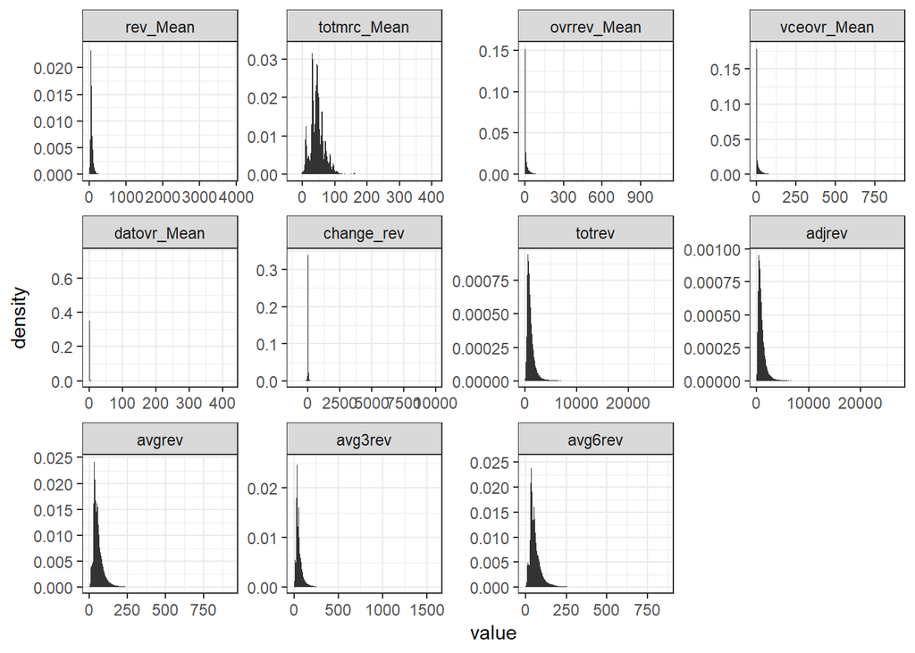

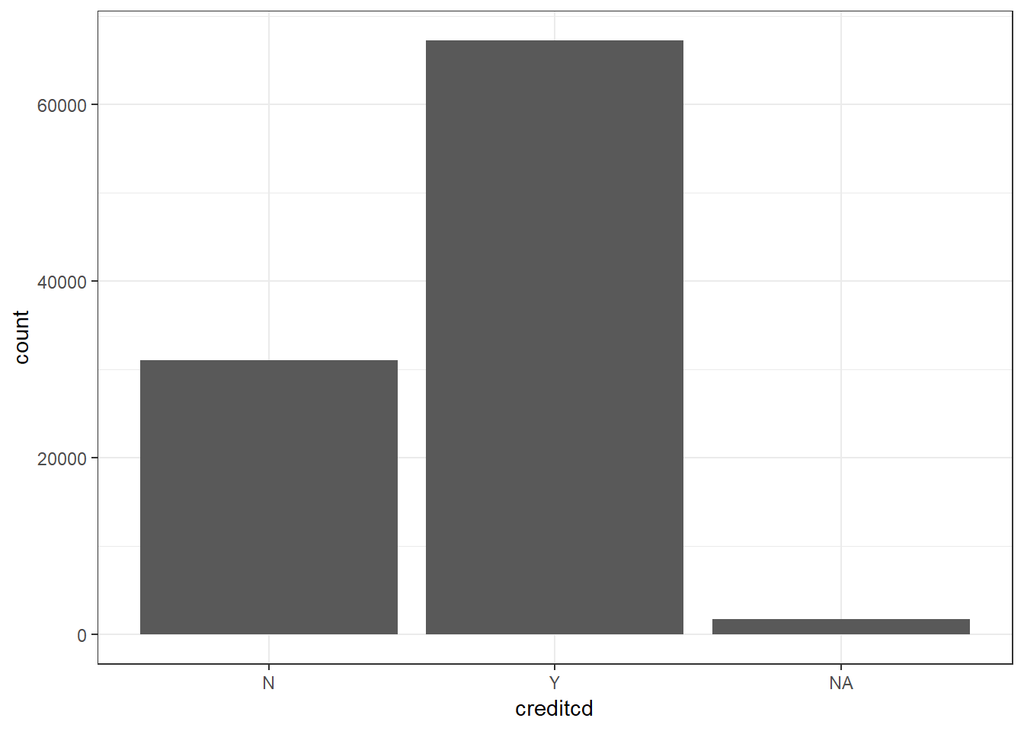

```
##     rev_Mean         totmrc_Mean      ovrrev_Mean       vceovr_Mean
##  Min.   :  -6.168   Min.   :-26.91   Min.   :   0.00   Min.   :  0.000
##  1st Qu.:  33.260   1st Qu.: 30.00   1st Qu.:   0.00   1st Qu.:  0.000
##  Median :  48.195   Median : 44.99   Median :   1.00   Median :  0.683
##  Mean   :  58.720   Mean   : 46.18   Mean   :  13.56   Mean   : 13.295
##  3rd Qu.:  70.750   3rd Qu.: 59.99   3rd Qu.:  14.44   3rd Qu.: 14.025
##  Max.   :3843.263   Max.   :409.99   Max.   :1102.40   Max.   :896.088
##  NA's   :357        NA's   :357      NA's   :357       NA's   :357
##   datovr_Mean         change_rev            totrev
##  Min.   :  0.0000   Min.   :-1107.740   Min.   :    3.65
##  1st Qu.:  0.0000   1st Qu.:   -7.365   1st Qu.:  518.98
##  Median :  0.0000   Median :   -0.315   Median :  804.53
##  Mean   :  0.2614   Mean   :   -1.021   Mean   : 1031.92
##  3rd Qu.:  0.0000   3rd Qu.:    1.643   3rd Qu.: 1263.77
##  Max.   :423.5400   Max.   : 9963.658   Max.   :27321.50
##  NA's   :357        NA's   :891
##      adjrev            avgrev          avg3rev           avg6rev
##  Min.   :    2.4   Min.   :  0.48   Min.   :   1.00   Min.   : -2.00
##  1st Qu.:  452.2   1st Qu.: 35.37   1st Qu.:  33.00   1st Qu.: 34.00
##  Median :  737.8   Median : 49.89   Median :  48.00   Median : 50.00
##  Mean   :  960.1   Mean   : 57.91   Mean   :  59.19   Mean   : 58.68
##  3rd Qu.: 1188.2   3rd Qu.: 69.48   3rd Qu.:  71.00   3rd Qu.: 71.00
##  Max.   :27071.3   Max.   :924.27   Max.   :1593.00   Max.   :866.00
##                                                       NA's   :2839
##    creditcd
##  Length:100000
##  Class :character
##  Mode  :character
##
##
##
##
```

rev_Mean - datovr_Mean

```
##      Customer_ID rev_Mean totmrc_Mean ovrrev_Mean vceovr_Mean datovr_Mean
## 225      1000225       NA          NA          NA          NA          NA
## 232      1000232       NA          NA          NA          NA          NA
## 979      1000979       NA          NA          NA          NA          NA
## 1832     1001832       NA          NA          NA          NA          NA
## 2604     1002604       NA          NA          NA          NA          NA
## 2860     1002860       NA          NA          NA          NA          NA
##      change_rev  totrev  adjrev avgrev avg3rev avg6rev creditcd
## 225          NA 3415.63 3340.28 128.47     142     163        Y
## 232          NA  523.50  505.00  15.30      10      13        N
## 979          NA 3865.41 3712.56 137.50     205     177        Y
## 1832         NA 5156.64 5022.48 156.95      97     135        Y
## 2604         NA  782.03  696.03  63.28      21      44        N
## 2860         NA  199.21  149.41  37.35      31      NA        N
```

change_rev

avg6rev

creditcd

Extreme Values

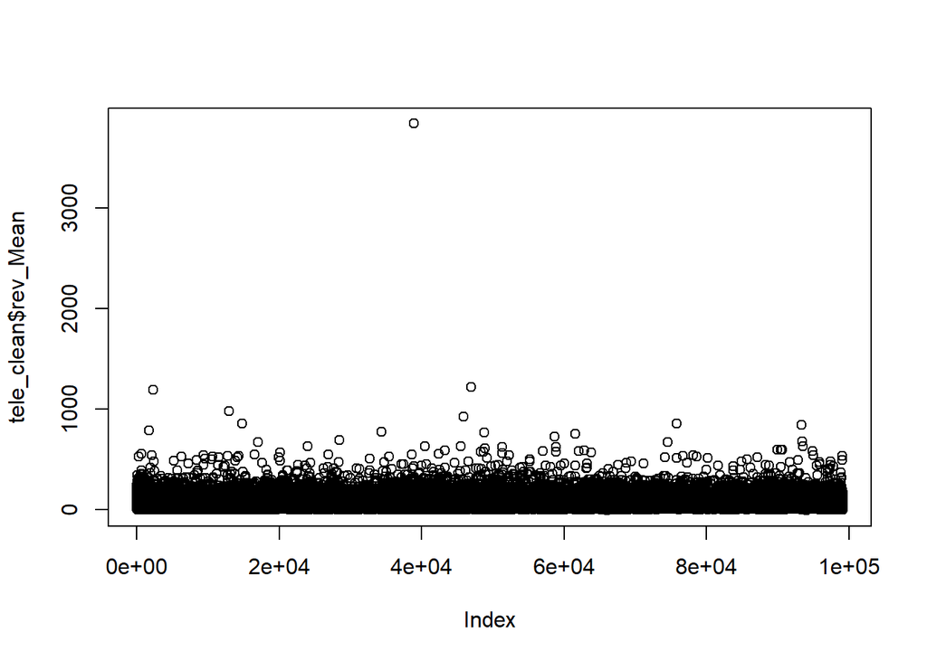

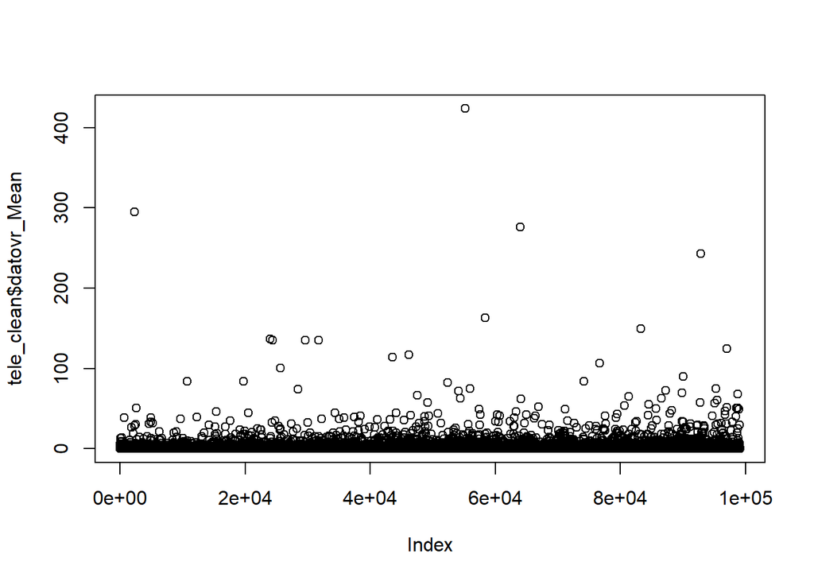

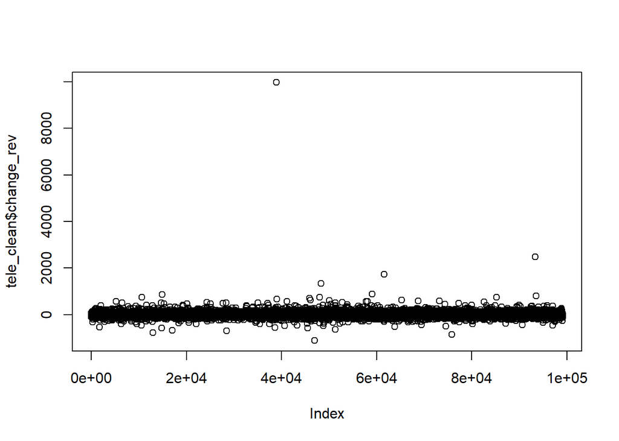

Customer

Class Types and Structure

```
## Observations: 100,000
## Variables: 30
## $ churn            <int> 1, 0, 1, 0, 0, 0, 1, 0, 0, 0, 0, 0, 0, 0, 0, ...
## $ months           <int> 61, 56, 58, 60, 57, 59, 53, 53, 55, 57, 59, 5...
## $ uniqsubs         <int> 2, 1, 1, 1, 1, 2, 2, 1, 1, 2, 2, 3, 1, 2, 5, ...
## $ actvsubs         <int> 1, 1, 1, 1, 1, 2, 2, 1, 1, 2, 2, 3, 1, 2, 1, ...
## $ crdlscod         <chr> "A", "EA", "C", "B", "A", "C", "A", "B", "B",...
## $ asl_flag         <chr> "N", "N", "N", "N", "N", "N", "N", "N", "N", ...
## $ prizm_social_one <chr> "S", "U", "S", "T", "U", "U", "C", NA, "S", "...
## $ area             <chr> "NORTHWEST/ROCKY MOUNTAIN AREA", "CHICAGO ARE...
## $ phones           <int> 2, 7, 2, 1, 6, 9, 4, 3, 3, 2, 3, 4, 9, 2, 10,...
## $ models           <int> 2, 6, 1, 1, 4, 4, 3, 2, 3, 2, 3, 3, 5, 2, 6, ...
## $ truck            <int> 0, 1, 0, 0, 0, 0, 0, 0, 0, 0, 0, 0, 0, 1, 0, ...
## $ rv               <int> 0, 1, 0, 0, 0, 0, 0, 0, 0, 0, 0, 0, 0, 0, 0, ...
## $ own_rent         <chr> "O", NA, "O", NA, "R", "O", "O", "R", NA, "O"...
```

[output cut: 17 more lines]

%NA

```
##            churn           months         uniqsubs         actvsubs
##            0.000            0.000            0.000            0.000
##         crdlscod         asl_flag prizm_social_one             area
##            0.000            0.000            7.388            0.040
##           phones           models            truck               rv
##            0.001            0.001            1.732            1.732
##         own_rent              lor         dwlltype          marital
##           33.706           30.190           31.909            1.732
##           adults         infobase           income         numbcars
##           23.019           22.079           25.436           49.366
##         HHStatin         dwllsize         forgntvl           ethnic
##           37.923           38.308            1.732            1.732
##           kid0_2           kid3_5          kid6_10         kid11_15
##            1.732            1.732            1.732            1.732
##         kid16_17      Customer_ID
##            1.732            0.000
```

Visualizing

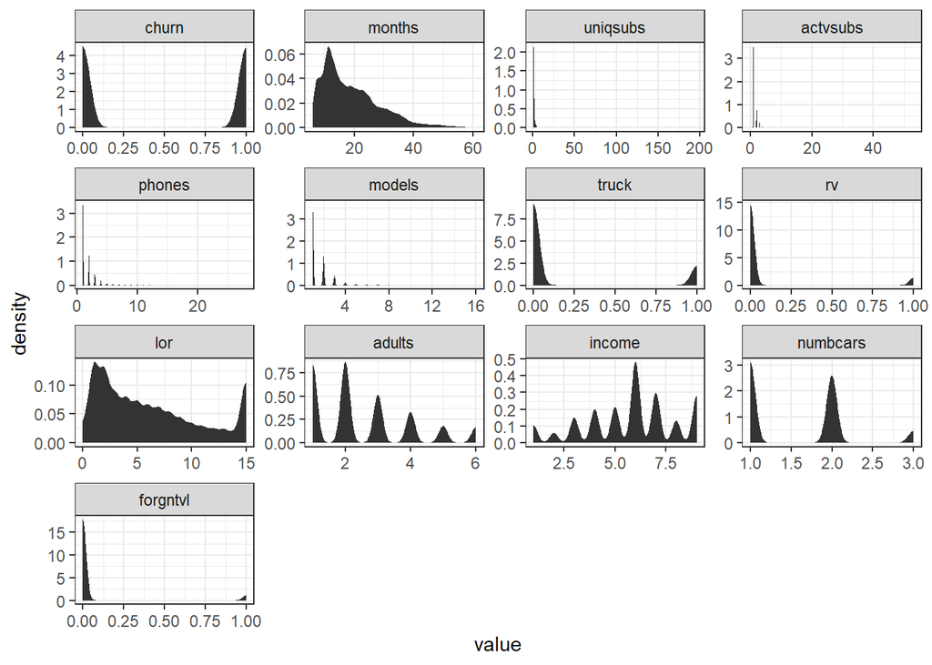

```
##      churn            months         uniqsubs          actvsubs
##  Min.   :0.0000   Min.   : 6.00   Min.   :  1.000   Min.   : 0.000
##  1st Qu.:0.0000   1st Qu.:11.00   1st Qu.:  1.000   1st Qu.: 1.000
##  Median :0.0000   Median :16.00   Median :  1.000   Median : 1.000
##  Mean   :0.4932   Mean   :18.78   Mean   :  1.546   Mean   : 1.358
##  3rd Qu.:1.0000   3rd Qu.:24.00   3rd Qu.:  2.000   3rd Qu.: 2.000
##  Max.   :1.0000   Max.   :61.00   Max.   :196.000   Max.   :53.000
##
##    crdlscod           asl_flag         prizm_social_one
##  Length:99109       Length:99109       Length:99109
##  Class :character   Class :character   Class :character
##  Mode  :character   Mode  :character   Mode  :character
##
##
##
##
##      area               phones           models           truck
##  Length:99109       Min.   : 1.000   Min.   : 1.000   Min.   :0.0000
##  Class :character   1st Qu.: 1.000   1st Qu.: 1.000   1st Qu.:0.0000
##  Mode  :character   Median : 1.000   Median : 1.000   Median :0.0000
##                     Mean   : 1.787   Mean   : 1.546   Mean   :0.1895
##                     3rd Qu.: 2.000   3rd Qu.: 2.000   3rd Qu.:0.0000
##                     Max.   :28.000   Max.   :16.000   Max.   :1.0000
##                     NA's   :1        NA's   :1        NA's   :1717
##        rv          own_rent              lor           dwlltype
##  Min.   :0.000   Length:99109       Min.   : 0.000   Length:99109
##  1st Qu.:0.000   Class :character   1st Qu.: 2.000   Class :character
##  Median :0.000   Mode  :character   Median : 5.000   Mode  :character
##  Mean   :0.083                      Mean   : 6.177
##  3rd Qu.:0.000                      3rd Qu.: 9.000
##  Max.   :1.000                      Max.   :15.000
##  NA's   :1717                       NA's   :29890
##    marital              adults        infobase             income
##  Length:99109       Min.   :1.000   Length:99109       Min.   :1.000
##  Class :character   1st Qu.:1.000   Class :character   1st Qu.:4.000
##  Mode  :character   Median :2.000   Mode  :character   Median :6.000
##                     Mean   :2.531                      Mean   :5.782
##                     3rd Qu.:3.000                      3rd Qu.:7.000
##                     Max.   :6.000                      Max.   :9.000
##                     NA's   :22776                      NA's   :25170
```

[output cut: 9 more lines]

```
##  Length:99109       Length:99109       Length:99109
##  Class :character   Class :character   Class :character
##  Mode  :character   Mode  :character   Mode  :character
##
##
##
##
##    kid6_10            kid11_15           kid16_17
##  Length:99109       Length:99109       Length:99109
##  Class :character   Class :character   Class :character
##  Mode  :character   Mode  :character   Mode  :character
##
##
##
##
```

churn

asl_flag

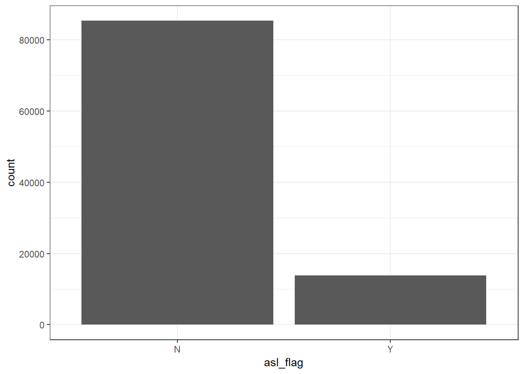

prizm_social_one

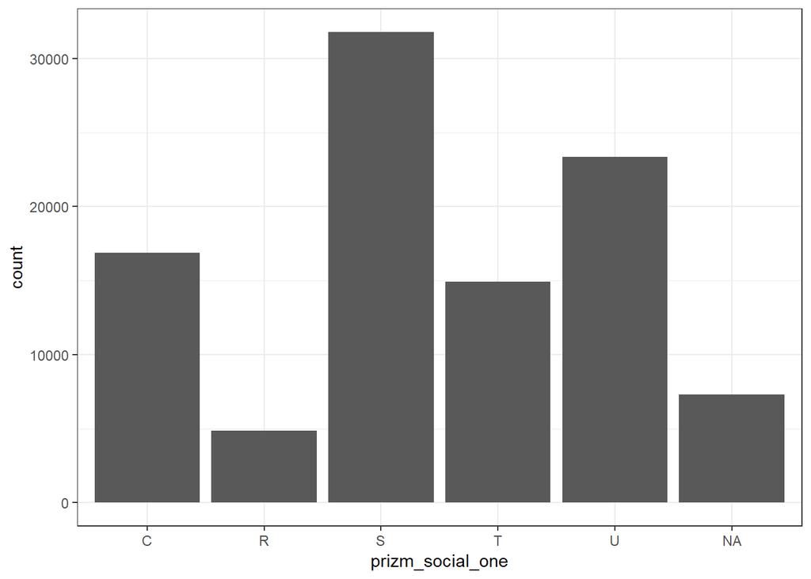

area

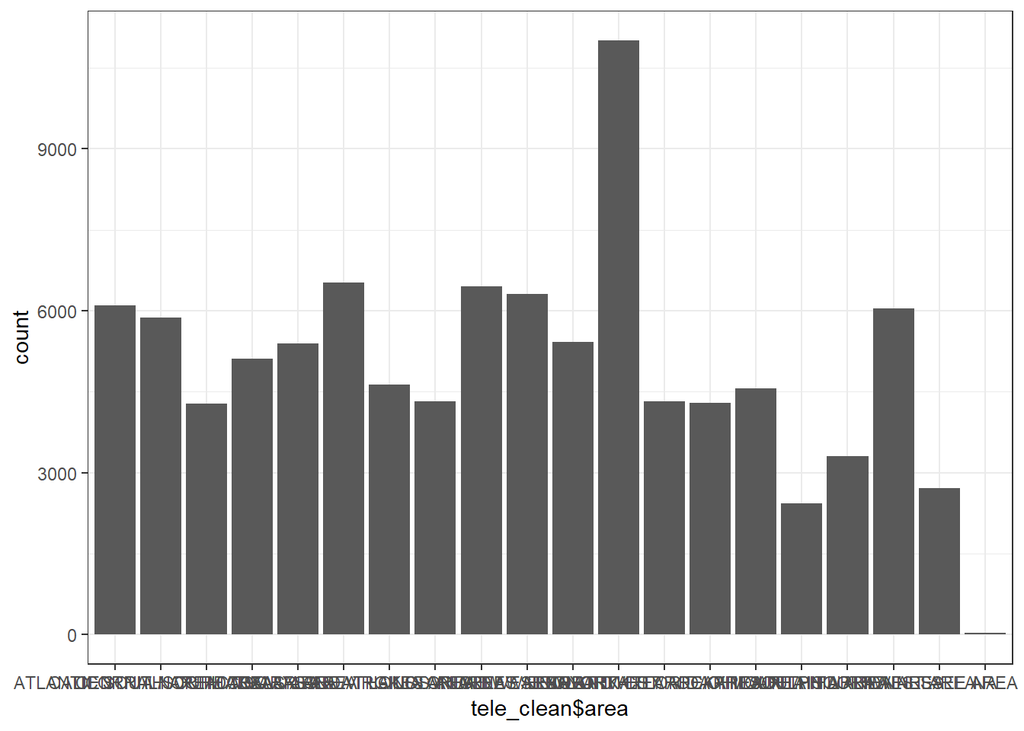

phones/models

```
## [1] TRUE
```

crdlscod

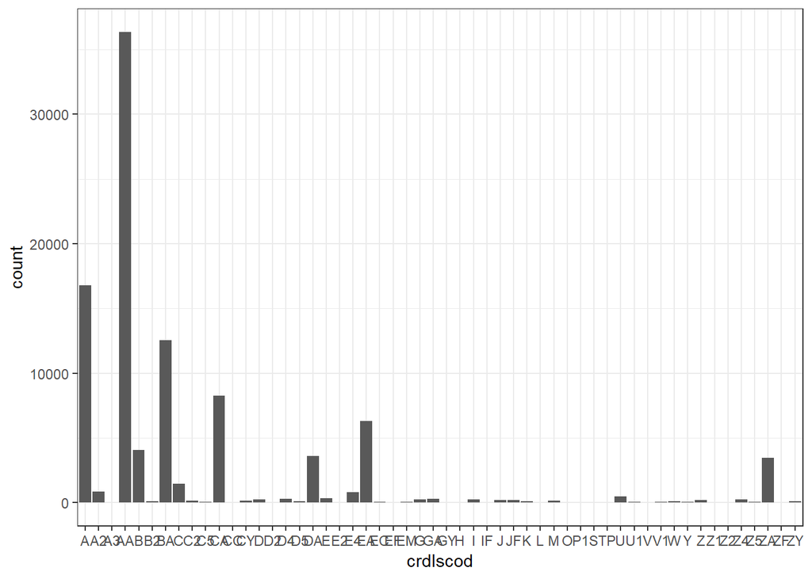

truck/rv

```
## [1] TRUE
```

own_rent

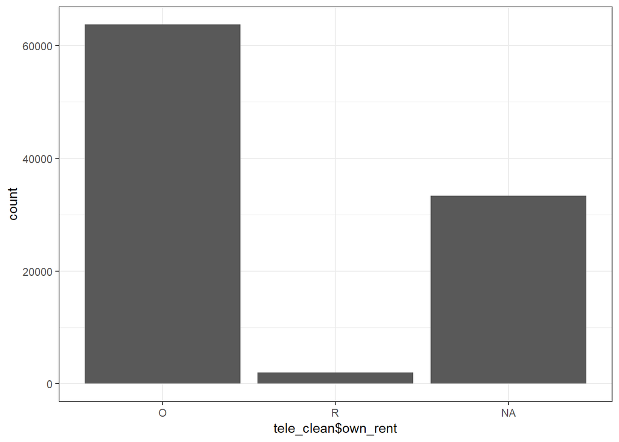

lor (length of residence in years)

adults

dwlltype

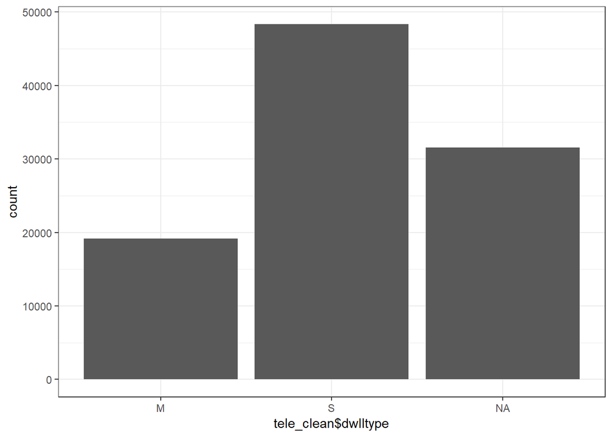

marital

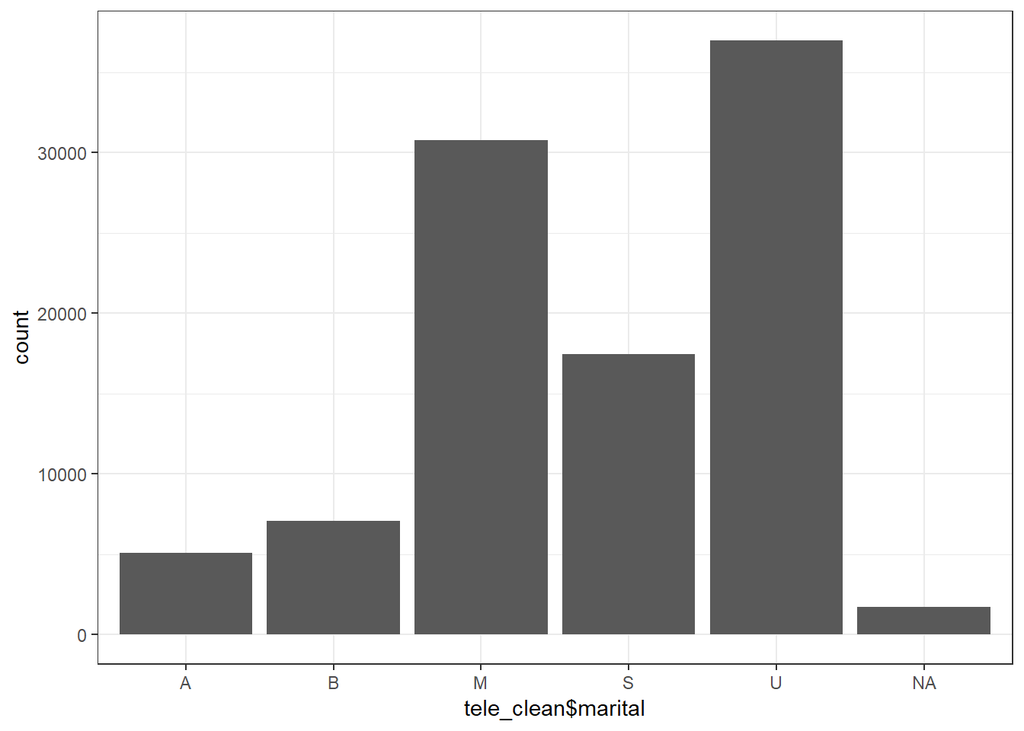

infobase

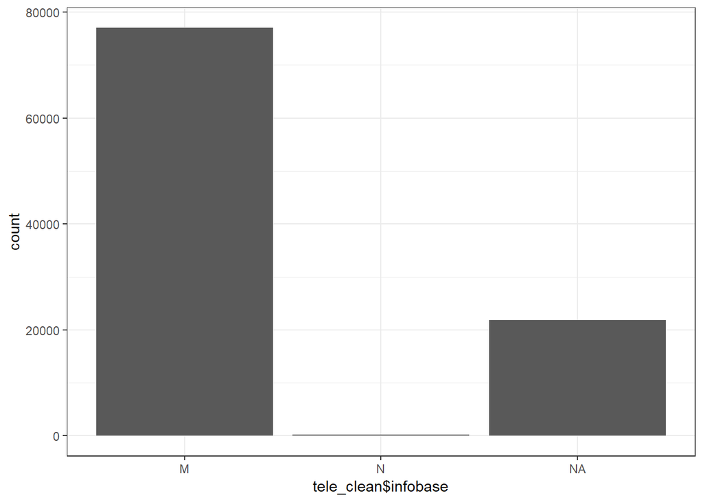

income (estimated)

numbcars

HHStatin

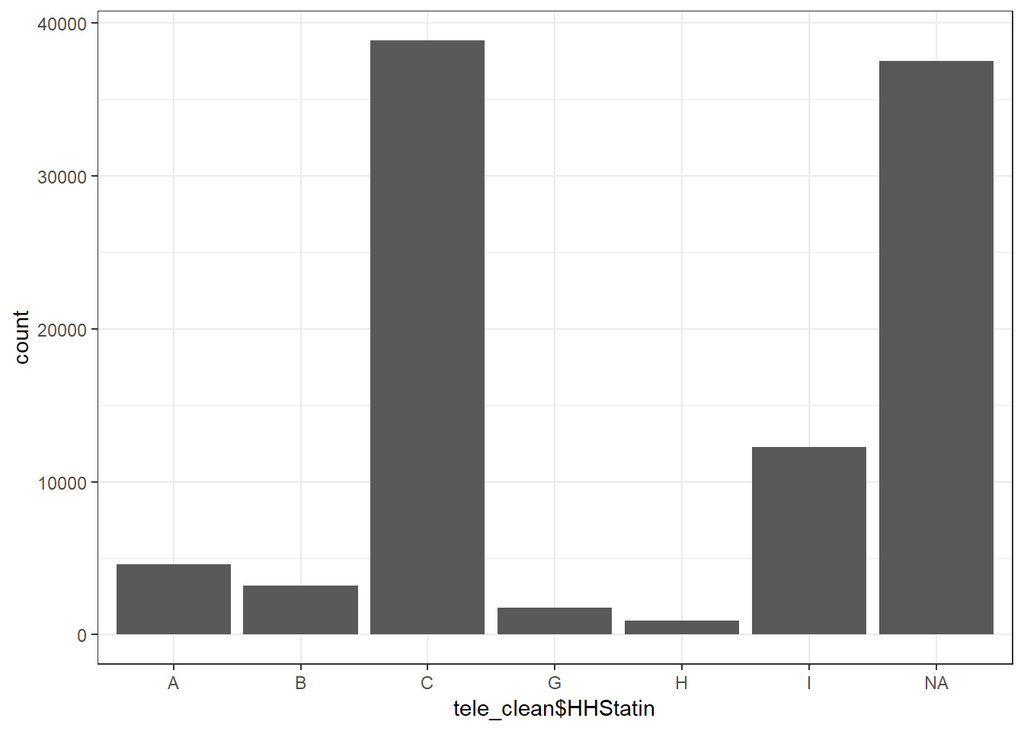

dwllsize

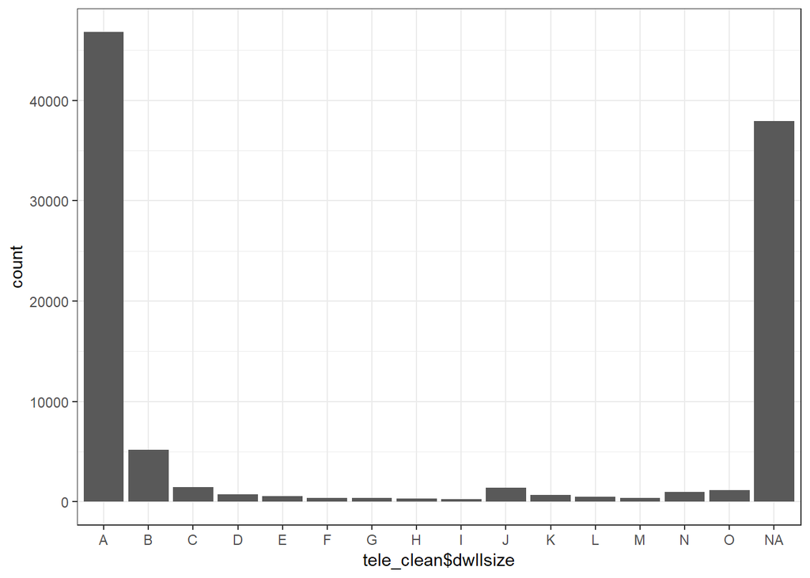

forgntvl

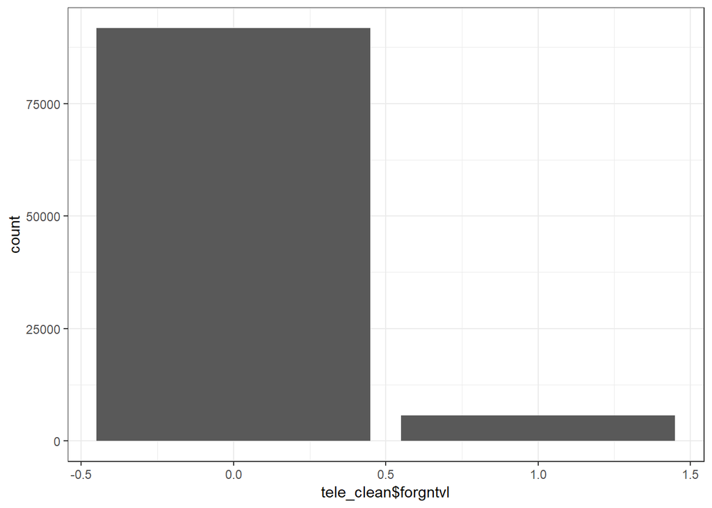

ethnic (Ethnicity roll-up code)

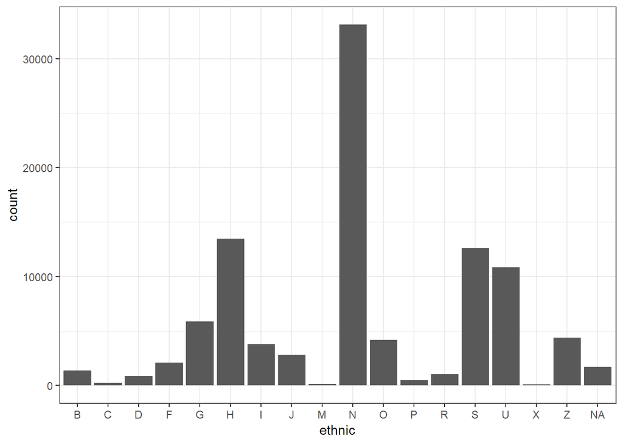

kids 0 -17

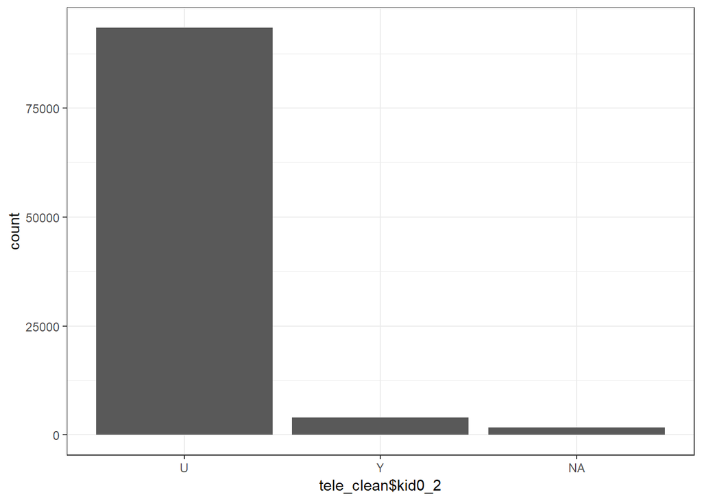

Extreme Values

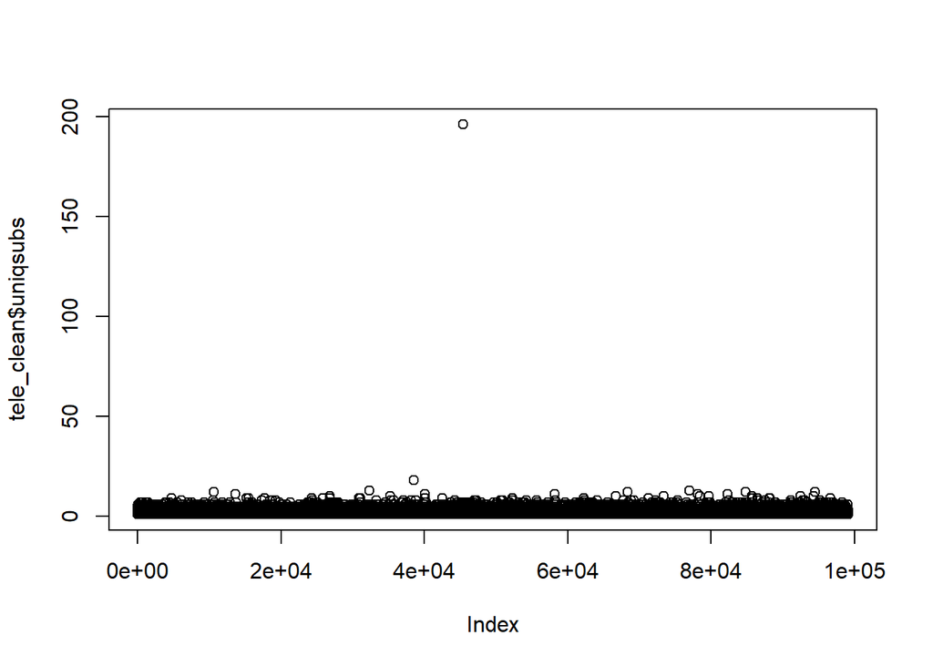

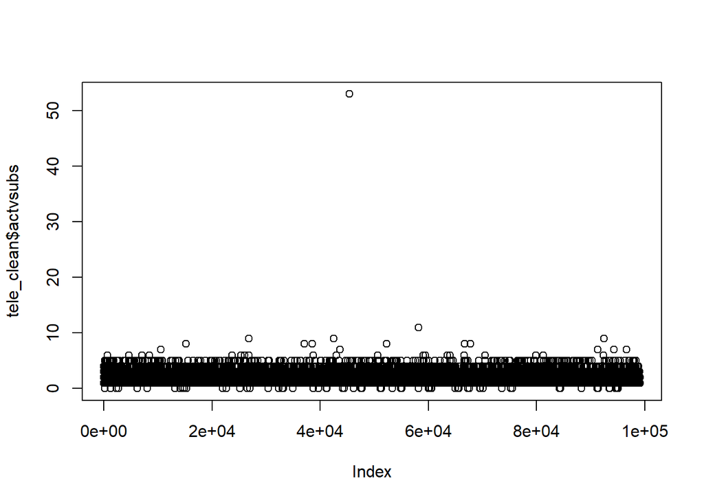

CustService

Class Types and Structure

```
## Observations: 100,000
## Variables: 4
## $ Customer_ID   <chr> "1000001", "1000002", "1000003", "1000004", "100...
## $ custcare_Mean <dbl> 0.000, 1.667, 0.000, 0.000, 8.667, 4.333, 0.000,...
## $ ccrndmou_Mean <dbl> 0.000, 6.333, 0.000, 0.000, 15.000, 11.000, 0.00...
## $ cc_mou_Mean   <dbl> 0.000, 5.463, 0.000, 0.000, 11.077, 7.753, 0.000...
```

%NA

```
##   Customer_ID custcare_Mean ccrndmou_Mean   cc_mou_Mean
##             0             0             0             0
```

Visualizing

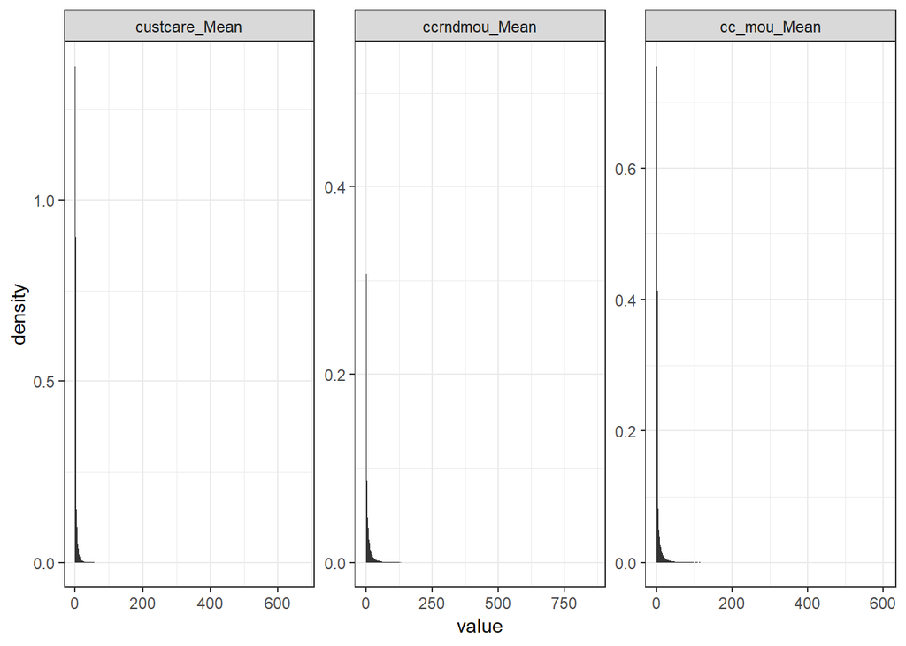

[output not shown]

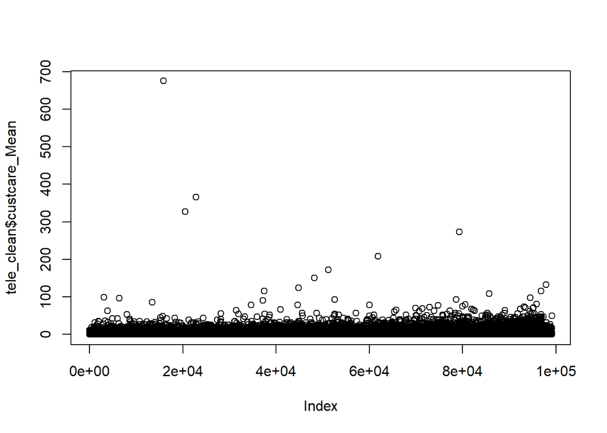

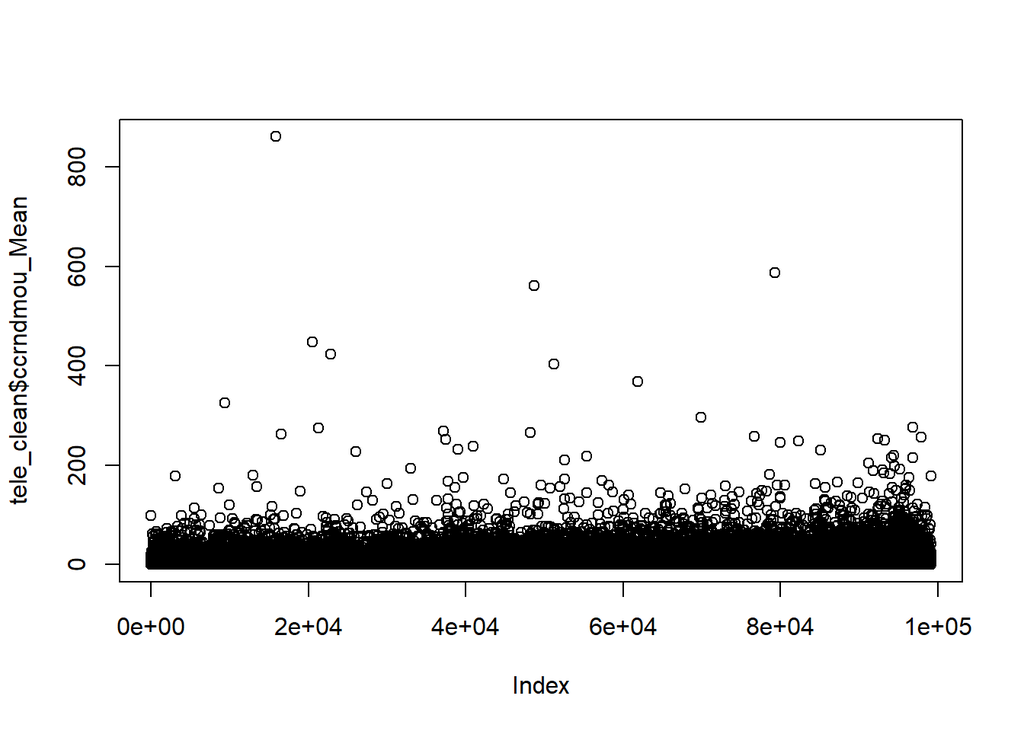

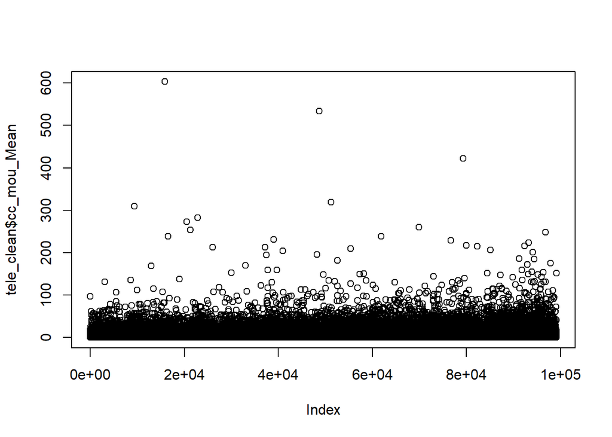

Operations

Class Types and Structure

```
## Observations: 100,000
## Variables: 37
## $ Customer_ID        <chr> "1000001", "1000002", "1000003", "1000004",...
## $ mou_Mean           <dbl> 219.25, 482.75, 10.25, 7.50, 570.50, 1312.2...
## $ da_Mean            <dbl> 0.248, 0.248, 0.000, 0.000, 0.000, 1.238, 0...
## $ ovrmou_Mean        <dbl> 0.00, 22.75, 0.00, 0.00, 0.00, 0.00, 0.00, ...
## $ roam_Mean          <dbl> 0.000, 0.000, 0.000, 0.000, 0.000, 0.000, 0...
## $ change_mou         <dbl> -157.25, 532.25, -4.25, -1.50, 38.50, 156.7...
## $ comp_vce_Mean      <dbl> 45.000, 193.333, 6.000, 3.667, 137.000, 577...
## $ comp_data_Mean     <dbl> 0.000, 0.000, 0.000, 0.000, 0.000, 0.000, 0...
## $ inonemin_Mean      <dbl> 18.000, 53.000, 0.333, 1.333, 66.000, 301.6...
## $ threeway_Mean      <dbl> 0.000, 0.333, 0.000, 0.000, 0.000, 1.333, 0...
## $ mou_compvce_Mean   <dbl> 90.643, 189.397, 5.427, 8.410, 285.233, 369...
## $ mou_compdata_Mean  <dbl> 0.000, 0.000, 0.000, 0.000, 0.000, 0.000, 0...
## $ mou_rvce_Mean      <dbl> 97.177, 55.280, 0.000, 0.413, 106.330, 200....
```

[output cut: 24 more lines]

%NA

```
##        Customer_ID           mou_Mean            da_Mean
##              0.000              0.357              0.357
##        ovrmou_Mean          roam_Mean         change_mou
##              0.357              0.357              0.891
##      comp_vce_Mean     comp_data_Mean      inonemin_Mean
##              0.000              0.000              0.000
##      threeway_Mean   mou_compvce_Mean  mou_compdata_Mean
##              0.000              0.000              0.000
##      mou_rvce_Mean    owylis_vce_Mean   mou_owylisv_Mean
##              0.000              0.000              0.000
##    iwylis_vce_Mean   mou_iwylisv_Mean      peak_vce_Mean
##              0.000              0.000              0.000
##     peak_data_Mean  mou_peak_vce_Mean mou_peak_data_Mean
##              0.000              0.000              0.000
##       opk_vce_Mean      opk_data_Mean   mou_opk_vce_Mean
##              0.000              0.000              0.000
##  mou_opk_data_Mean      callfwdv_Mean      callwait_Mean
##              0.000              0.000              0.000
##           totcalls             totmou             adjmou
##              0.000              0.000              0.000
##             adjqty             avgmou             avgqty
##              0.000              0.000              0.000
##            avg3mou            avg3qty            avg6mou
##              0.000              0.000              2.839
##            avg6qty
##              2.839
```

Visualizing part 1

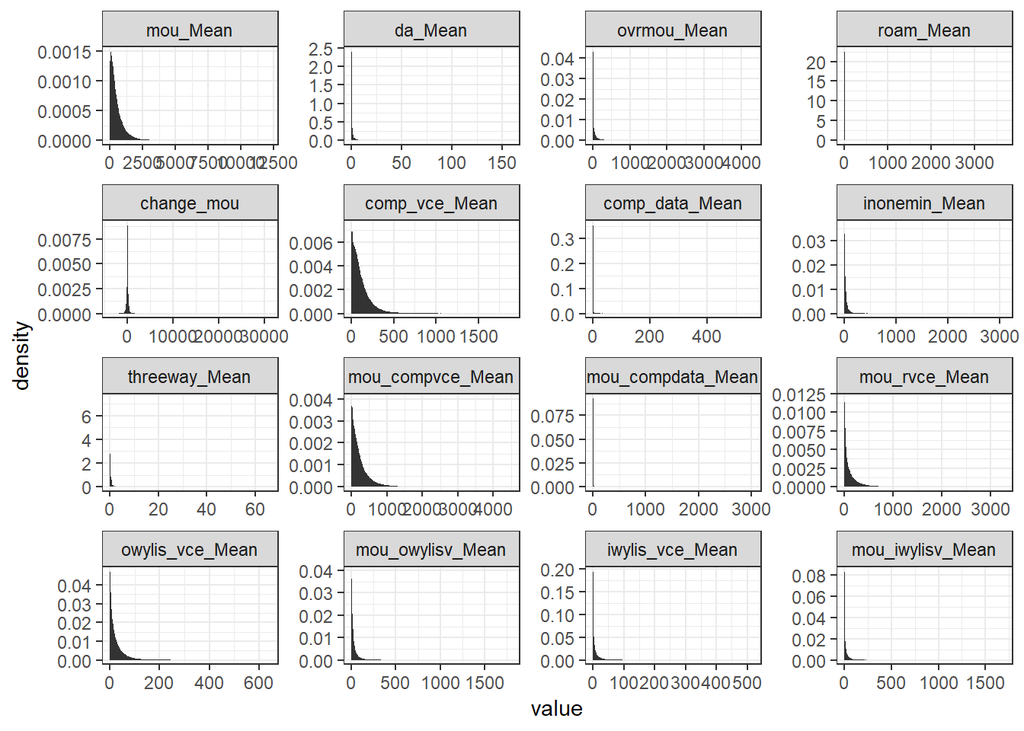

Visualizing part 2

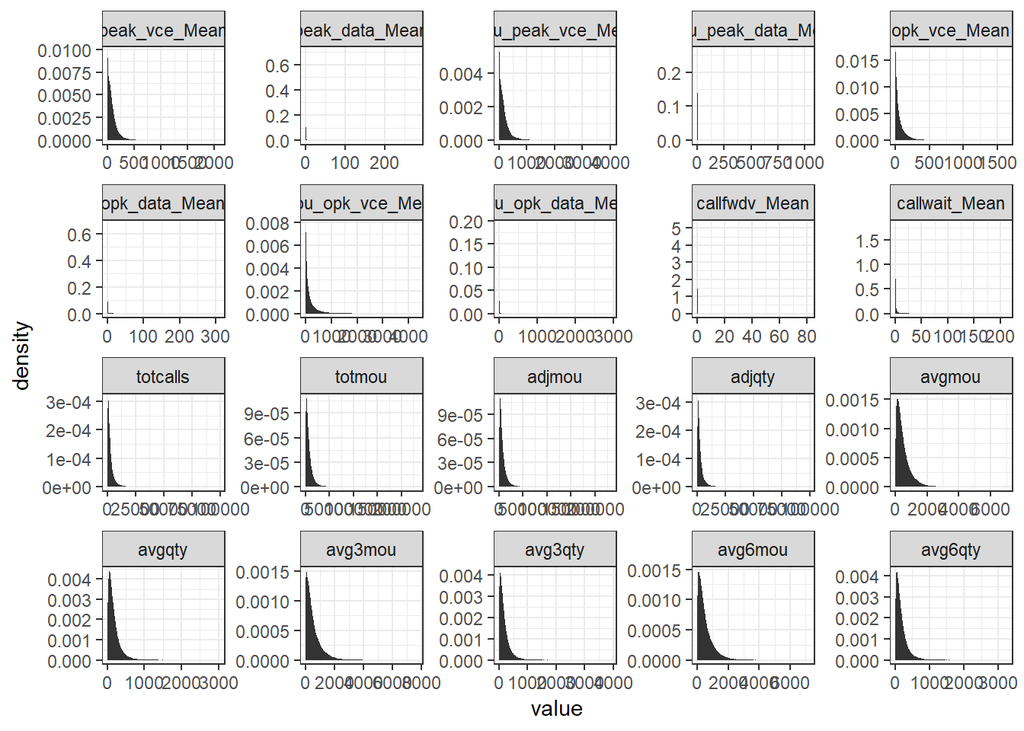

```
##     da_Mean          ovrmou_Mean        roam_Mean
##  Min.   :  0.0000   Min.   :   0.00   Min.   :   0.000
##  1st Qu.:  0.0000   1st Qu.:   0.00   1st Qu.:   0.000
##  Median :  0.2480   Median :   3.00   Median :   0.000
##  Mean   :  0.8905   Mean   :  41.08   Mean   :   1.286
##  3rd Qu.:  0.9900   3rd Qu.:  42.25   3rd Qu.:   0.235
##  Max.   :159.3900   Max.   :4320.75   Max.   :3685.200
##
##    change_mou       comp_vce_Mean    comp_data_Mean   inonemin_Mean
##  Min.   :-3875.00   Min.   :   0.0   Min.   :  0.00   Min.   :   0.000
##  1st Qu.:  -87.00   1st Qu.:  29.0   1st Qu.:  0.00   1st Qu.:   2.667
##  Median :   -6.25   Median :  76.0   Median :  0.00   Median :  12.667
##  Mean   :  -13.93   Mean   : 109.3   Mean   :  0.78   Mean   :  29.852
##  3rd Qu.:   63.00   3rd Qu.: 150.3   3rd Qu.:  0.00   3rd Qu.:  35.667
##  Max.   :31219.25   Max.   :1894.3   Max.   :559.33   Max.   :3086.667
##
##  threeway_Mean     mou_compvce_Mean  mou_compdata_Mean  mou_rvce_Mean
##  Min.   : 0.0000   Min.   :   0.00   Min.   :   0.000   Min.   :   0.000
##  1st Qu.: 0.0000   1st Qu.:  49.98   1st Qu.:   0.000   1st Qu.:   7.892
##  Median : 0.0000   Median : 147.06   Median :   0.000   Median :  50.635
##  Mean   : 0.2857   Mean   : 228.64   Mean   :   1.857   Mean   : 112.071
##  3rd Qu.: 0.3330   3rd Qu.: 310.46   3rd Qu.:   0.000   3rd Qu.: 150.072
##  Max.   :66.0000   Max.   :4514.45   Max.   :3032.050   Max.   :3287.250
##
##  owylis_vce_Mean  mou_owylisv_Mean  iwylis_vce_Mean   mou_iwylisv_Mean
##  Min.   :  0.00   Min.   :   0.00   Min.   :  0.000   Min.   :   0.00
##  1st Qu.:  3.00   1st Qu.:   2.45   1st Qu.:  0.000   1st Qu.:   0.00
##  Median : 13.00   Median :  12.08   Median :  2.000   Median :   3.28
##  Mean   : 24.85   Mean   :  28.56   Mean   :  7.928   Mean   :  18.27
##  3rd Qu.: 33.00   3rd Qu.:  34.31   3rd Qu.:  8.667   3rd Qu.:  18.35
##  Max.   :644.33   Max.   :1802.71   Max.   :519.333   Max.   :1703.54
##
##  peak_vce_Mean     peak_data_Mean     mou_peak_vce_Mean
##  Min.   :   0.00   Min.   :  0.0000   Min.   :   0.00
##  1st Qu.:  22.00   1st Qu.:  0.0000   1st Qu.:  38.42
##  Median :  60.67   Median :  0.0000   Median : 116.13
##  Mean   :  88.79   Mean   :  0.3608   Mean   : 174.69
##  3rd Qu.: 119.00   3rd Qu.:  0.0000   3rd Qu.: 233.94
##  Max.   :2090.67   Max.   :281.0000   Max.   :4015.35
##
```

[output cut: 25 more lines]

```
##  Min.   :   0.0   Min.   :   0.0   Min.   :   0.0   Min.   :   0.0
##  1st Qu.: 176.2   1st Qu.:  64.0   1st Qu.: 152.0   1st Qu.:  55.0
##  Median : 360.1   Median : 127.4   Median : 358.0   Median : 126.0
##  Mean   : 483.8   Mean   : 173.5   Mean   : 520.4   Mean   : 180.6
##  3rd Qu.: 655.6   3rd Qu.: 228.4   3rd Qu.: 712.0   3rd Qu.: 240.0
##  Max.   :7040.1   Max.   :3017.1   Max.   :7716.0   Max.   :3909.0
##
##     avg6mou          avg6qty         new_cell
##  Min.   :   0.0   Min.   :   0.0   Length:99108
##  1st Qu.: 164.0   1st Qu.:  59.0   Class :character
##  Median : 363.0   Median : 127.0   Mode  :character
##  Mean   : 509.9   Mean   : 178.4
##  3rd Qu.: 698.0   3rd Qu.: 237.0
##  Max.   :7217.0   Max.   :3256.0
##  NA's   :2761     NA's   :2761
```

avg6mou and avg6qty

Extreme Values

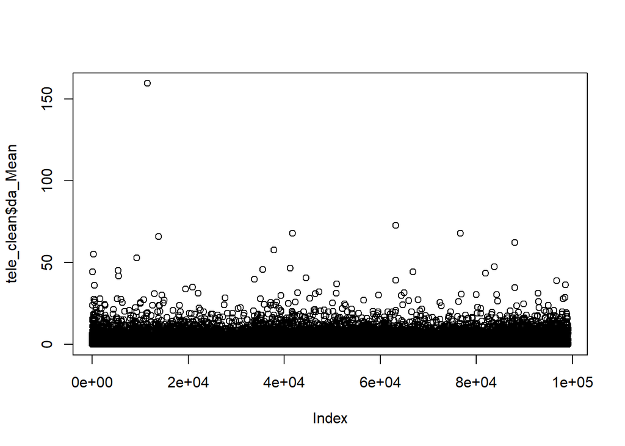

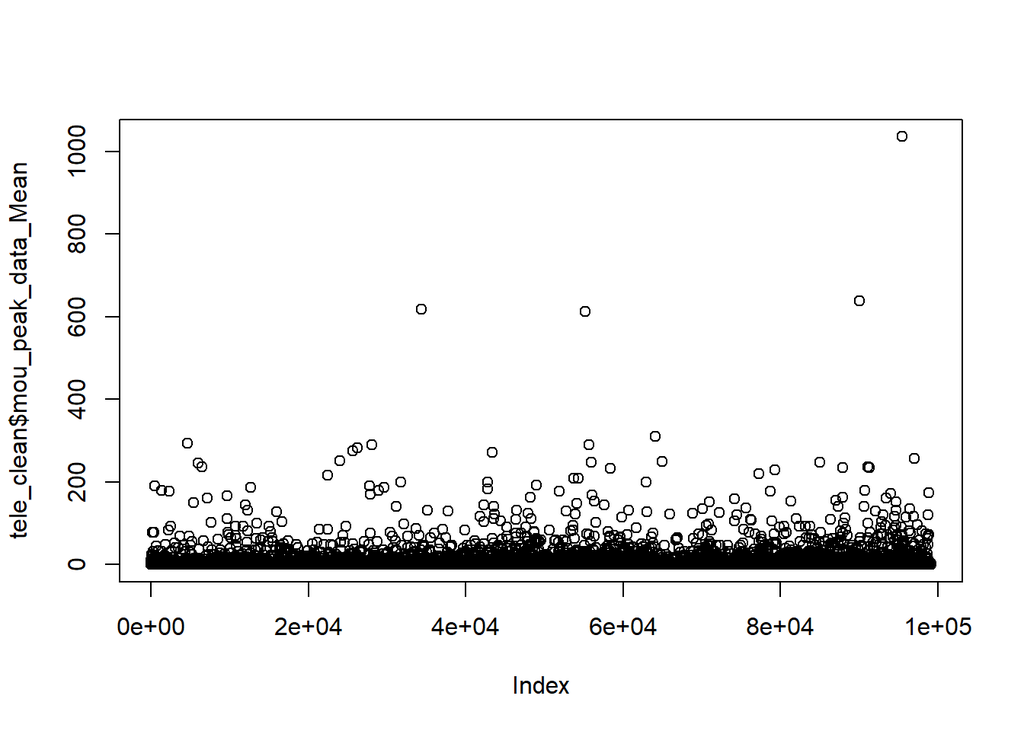

Product